# sem

harshini

2022-06-27

```r
covid19 <- read.csv(file.choose(), header = T)
```

View the Dimesnion of the Data Set

```r
dim(covid19)
```

```
## [1] 1925  231
```

view the first 6 values of the dataset using the head function

```r
head(covid19)
```

```
##   PATIENT_VISIT_IDENTIFIER AGE_ABOVE65 AGE_PERCENTIL GENDER DISEASE.GROUPING.1
## 1                        0           1          60th      0                  0
## 2                        0           1          60th      0                  0
## 3                        0           1          60th      0                  0
## 4                        0           1          60th      0                  0
## 5                        0           1          60th      0                  0
## 6                        1           1          90th      1                  0
##   DISEASE.GROUPING.2 DISEASE.GROUPING.3 DISEASE.GROUPING.4 DISEASE.GROUPING.5
## 1                  0                  0                  0                  1
## 2                  0                  0                  0                  1
## 3                  0                  0                  0                  1
## 4                  0                  0                  0                  1
## 5                  0                  0                  0                  1
## 6                  0                  0                  0                  0
##   DISEASE.GROUPING.6 HTN IMMUNOCOMPROMISED OTHER ALBUMIN_MEDIAN ALBUMIN_MEAN
```

[output cut: 349 more lines]

view the last 6 values of the dataset using the tail function

```r
tail(covid19)
```

```
##      PATIENT_VISIT_IDENTIFIER AGE_ABOVE65 AGE_PERCENTIL GENDER
## 1920                      383           0          40th      1
## 1921                      384           0          50th      1
## 1922                      384           0          50th      1
## 1923                      384           0          50th      1
## 1924                      384           0          50th      1
## 1925                      384           0          50th      1
##      DISEASE.GROUPING.1 DISEASE.GROUPING.2 DISEASE.GROUPING.3
## 1920                  0                  0                  0
## 1921                  0                  0                  0
## 1922                  0                  0                  0
## 1923                  0                  0                  0
## 1924                  0                  0                  0
## 1925                  0                  0                  1
##      DISEASE.GROUPING.4 DISEASE.GROUPING.5 DISEASE.GROUPING.6 HTN
```

[output cut: 370 more lines]

view the structure of the dataset

```r
str(covid19)
```

```
## 'data.frame':    1925 obs. of  231 variables:
##  $ PATIENT_VISIT_IDENTIFIER        : int  0 0 0 0 0 1 1 1 1 1 ...
##  $ AGE_ABOVE65                     : int  1 1 1 1 1 1 1 1 1 1 ...
##  $ AGE_PERCENTIL                   : chr  "60th" "60th" "60th" "60th" ...
##  $ GENDER                          : int  0 0 0 0 0 1 1 1 1 1 ...
##  $ DISEASE.GROUPING.1              : int  0 0 0 0 0 0 0 0 0 0 ...
##  $ DISEASE.GROUPING.2              : int  0 0 0 0 0 0 0 0 0 0 ...
##  $ DISEASE.GROUPING.3              : int  0 0 0 0 0 0 0 0 0 0 ...
##  $ DISEASE.GROUPING.4              : int  0 0 0 0 0 0 0 0 0 0 ...
##  $ DISEASE.GROUPING.5              : int  1 1 1 1 1 0 0 0 0 1 ...
##  $ DISEASE.GROUPING.6              : int  1 1 1 1 1 0 0 0 0 0 ...
##  $ HTN                             : int  0 0 0 0 0 1 1 1 1 1 ...
##  $ IMMUNOCOMPROMISED               : int  0 0 0 0 0 1 1 1 1 1 ...
##  $ OTHER                           : int  1 1 1 1 1 1 1 1 1 1 ...
##  $ ALBUMIN_MEDIAN                  : num  NA NA 0.605 NA 0 ...
```

[output cut: 86 more lines]

summary statistics for key variables.

The Mean value of The icu Columns is 0.2675325.

```r
mean(covid19$ICU)
```

```
## [1] 0.2675325
```

The Median value of The icu Columns is 0

```r
median(covid19$ICU)
```

```
## [1] 0
```

The variance of The icu Columns is 0.1960607

```r
var(covid19$ICU)
```

```
## [1] 0.1960607
```

The sd of The icu Columns is 0.4427874

```r
sd(covid19$ICU)
```

```
## [1] 0.4427874
```

The range values of The icu Columns is 0 to 1.

```r
range(covid19$ICU)
```

```
## [1] 0 1
```

The Minimum value of The icu Columns is 0.

```r
min(covid19$ICU)
```

```
## [1] 0
```

The Maximum value of The icu Columns is 1

```r
max(covid19$ICU)
```

```
## [1] 1
```

view the other column of the dataset using table function

table function is mainly used for count the values in the certain variable.

```r
table(covid19$AGE_PERCENTIL)
```

```
##
##       10th       20th       30th       40th       50th       60th       70th
##        205        215        205        200        190        185        195
##       80th       90th Above 90th
##        190        155        185
```

```r
table(covid19$GENDER)
```

```
##
##    0    1
## 1215  710
```

```r
table(covid19$AGE_ABOVE65)
```

```
##
##    0    1
## 1025  900
```

```r
table(covid19$DIMER_MAX)
```

[output not shown]

[output cut: 70 more lines]

[output not shown]

Histogram Chart for some numerical or continous variables.

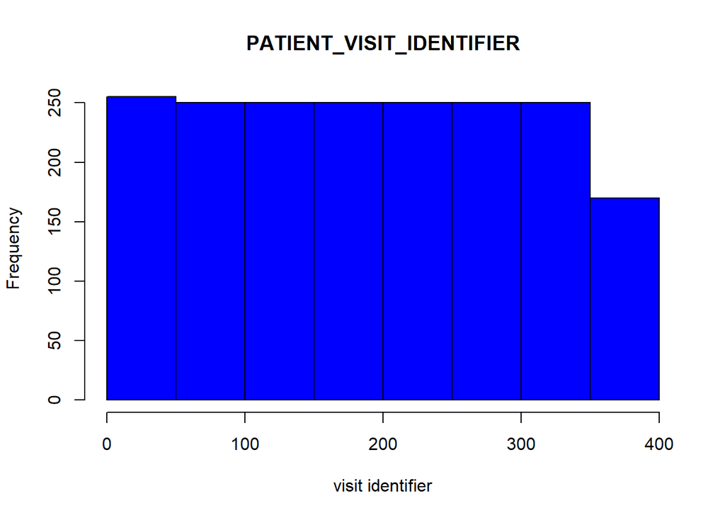

```r
hist(covid19$PATIENT_VISIT_IDENTIFIER,col='blue',main='PATIENT_VISIT_IDENTIFIER',xlab = 'visit identifier')
```

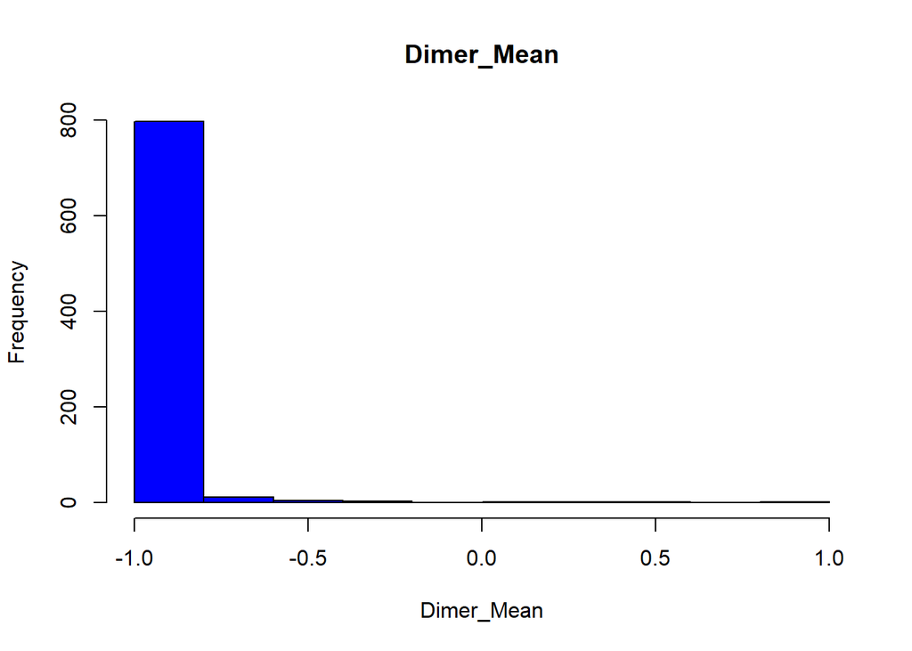

```r
hist(covid19$DIMER_MEAN,col='blue',main='Dimer_Mean',xlab = 'Dimer_Mean')
```

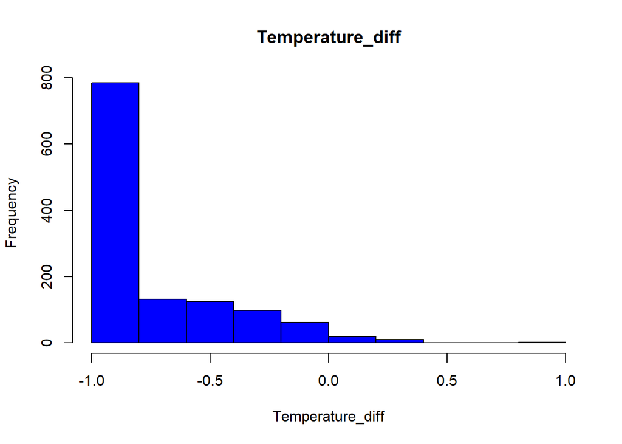

```r
hist(covid19$TEMPERATURE_DIFF,col='blue',main='Temperature_diff',xlab = 'Temperature_diff')
```

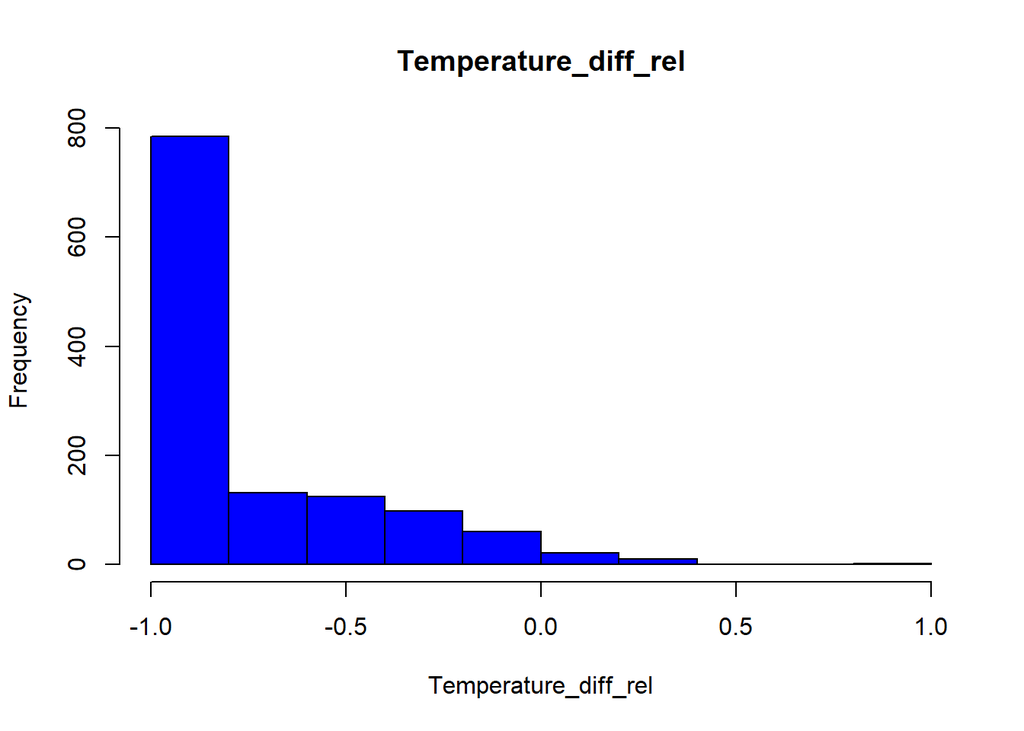

```r
hist(covid19$TEMPERATURE_DIFF_REL,col='blue',main='Temperature_diff_rel',xlab = 'Temperature_diff_rel')
```

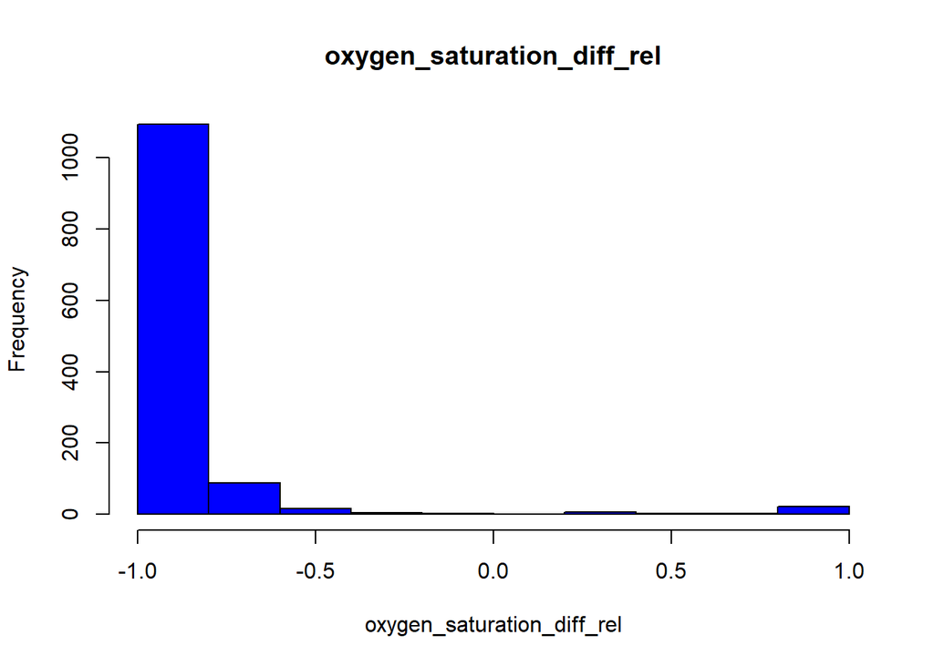

```r
hist(covid19$OXYGEN_SATURATION_DIFF_REL,col='blue',main='oxygen_saturation_diff_rel',xlab = 'oxygen_saturation_diff_rel')
```

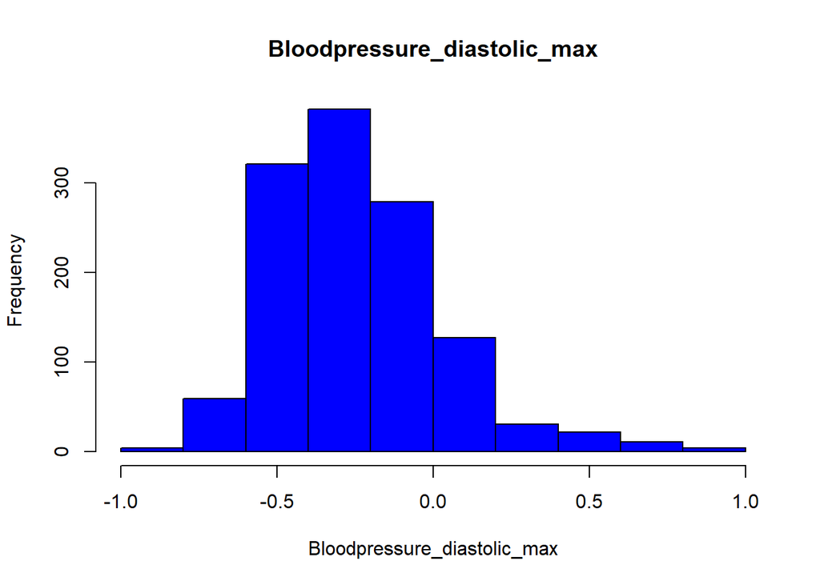

```r
hist(covid19$BLOODPRESSURE_DIASTOLIC_MAX,col='blue',main='Bloodpressure_diastolic_max',xlab = 'Bloodpressure_diastolic_max')
```

Boxplot for continous variables.

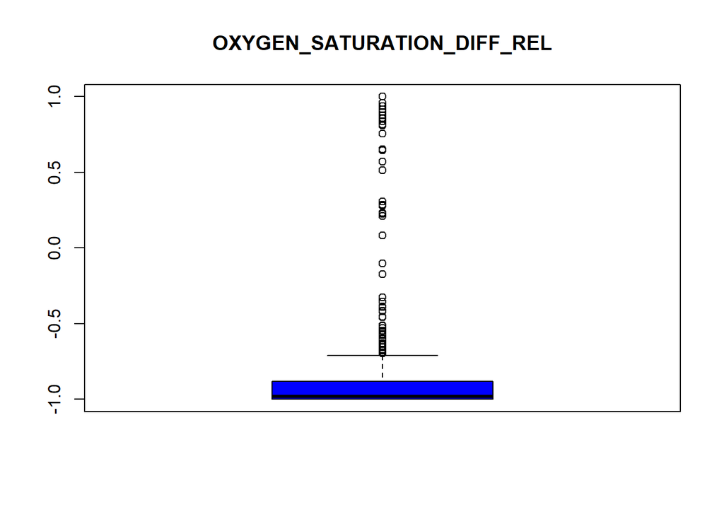

```r
boxplot(covid19$OXYGEN_SATURATION_DIFF_REL,col = 'blue',main='OXYGEN_SATURATION_DIFF_REL')
```

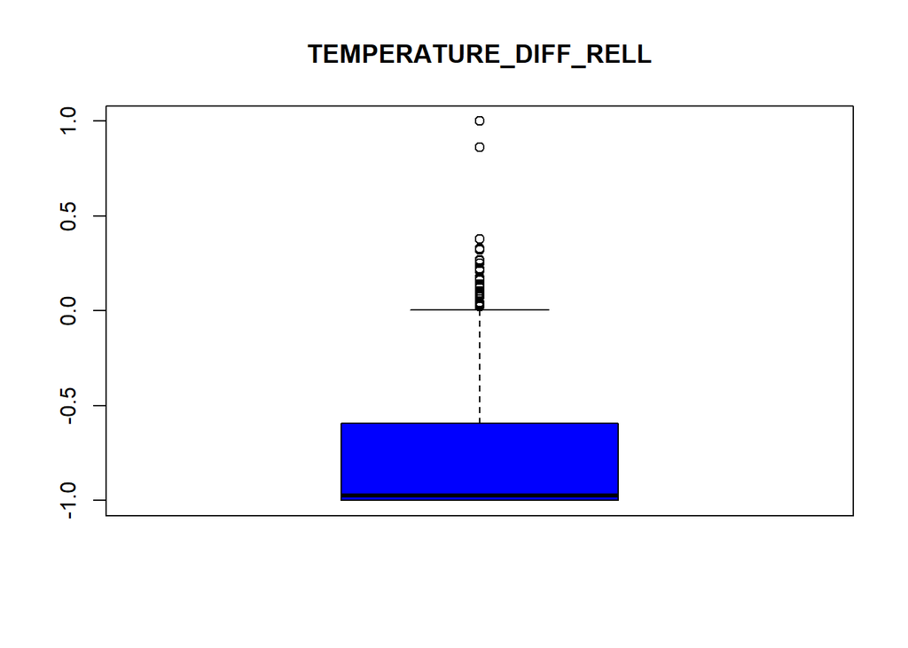

```r
boxplot(covid19$TEMPERATURE_DIFF_REL,col = 'blue',main='TEMPERATURE_DIFF_RELL')
```

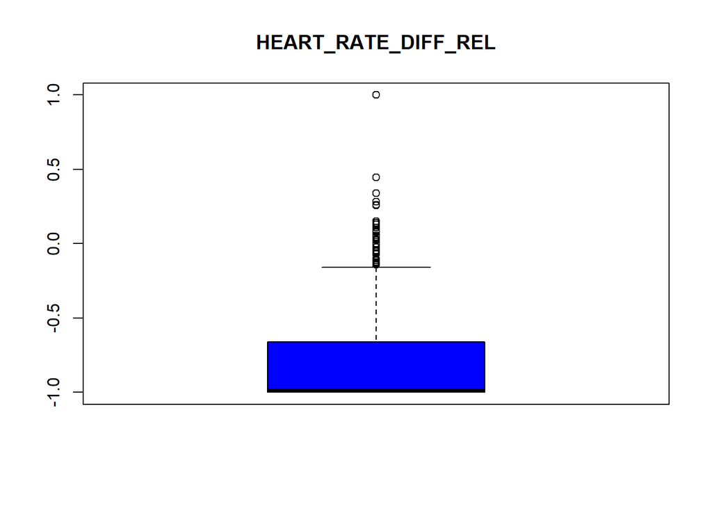

```r
boxplot(covid19$HEART_RATE_DIFF_REL,col = 'blue',main='HEART_RATE_DIFF_REL')
```

Boxplot for 2 variables

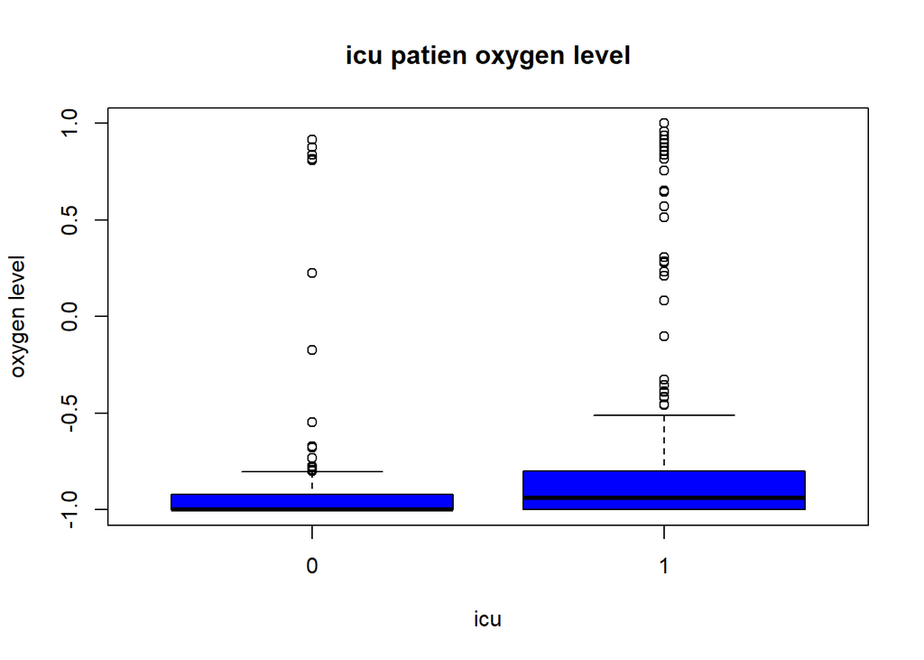

```r
boxplot(covid19$OXYGEN_SATURATION_DIFF_REL~covid19$ICU,col= 'blue',main='icu patien oxygen level',xlab = 'icu',ylab = 'oxygen level')
```

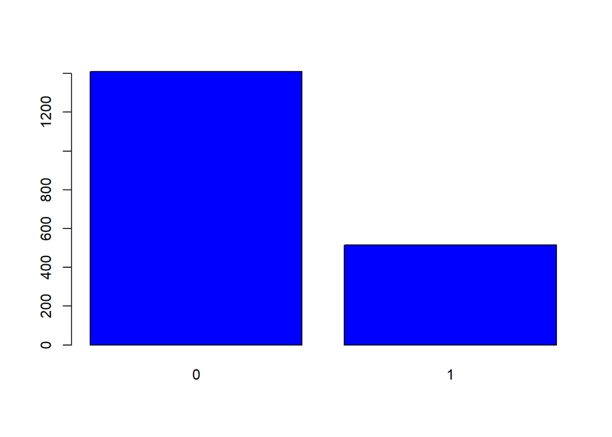

```r
barplot(table(covid19$ICU),table(covid19$ALBUMIN_DIFF),col='blue')
```

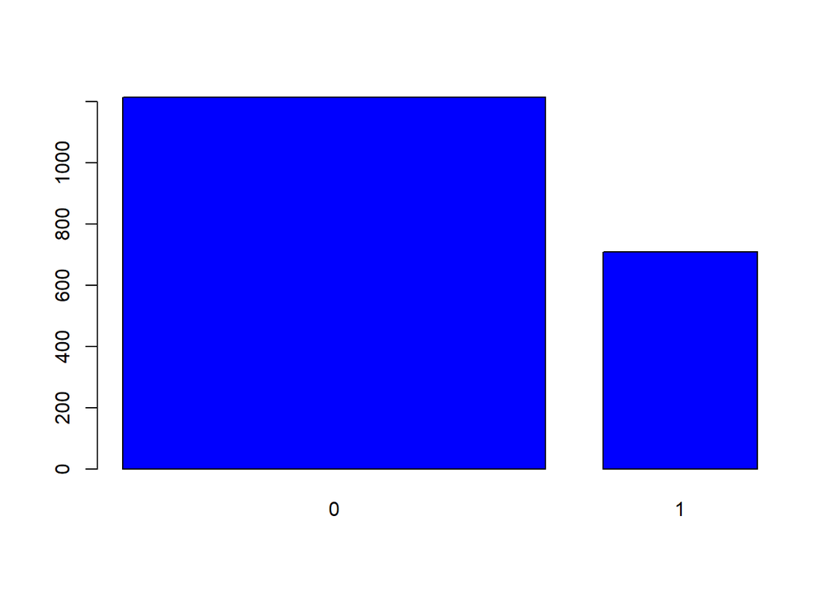

```r
barplot(table(covid19$GENDER),table(covid19$ICU),col = 'blue')
```

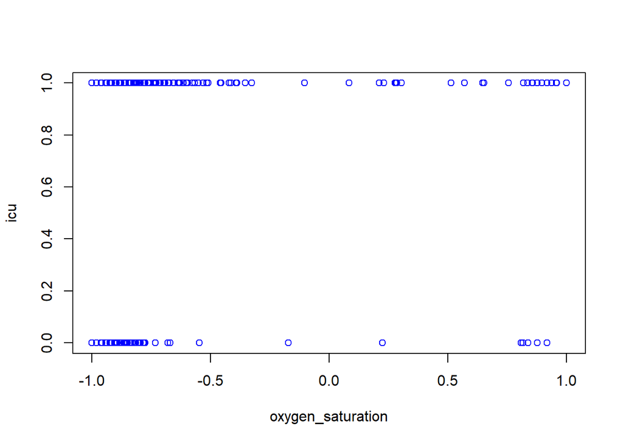

```r
plot(covid19$ICU~covid19$OXYGEN_SATURATION_DIFF_REL,col='blue',xlab='oxygen_saturation',ylab = 'icu')
```

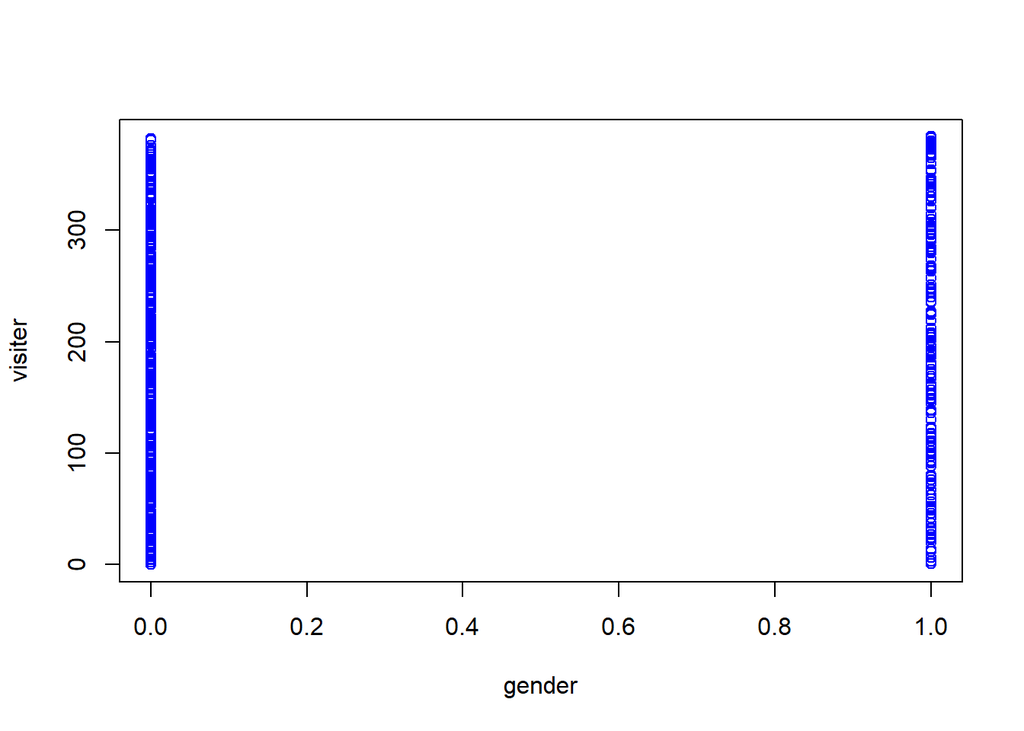

```r
plot(covid19$PATIENT_VISIT_IDENTIFIER~covid19$GENDER,col='blue',xlab='gender',ylab='visiter')
```

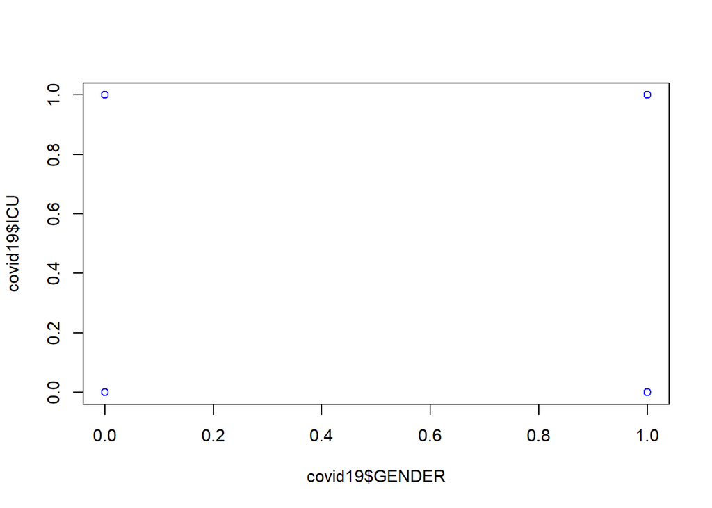

```r
plot(covid19$GENDER,covid19$ICU,col='blue')
```

[figure not shown]

```r
plot(covid19$AGE_ABOVE65,covid19$BLOODPRESSURE_DIASTOLIC_DIFF_REL,col='blue',xlab='bloodpressure',ylab = 'Age')
```

[figure not shown]

```r
plot(covid19$ICU~covid19$AGE_ABOVE65,col='blue',xlab='gender',ylab='icu')
```

Here I Found correlation for some features

```r
cor(covid19$PATIENT_VISIT_IDENTIFIER,covid19$ICU)
```

```
## [1] -0.04754667
```

```r
cor(covid19$GENDER,covid19$ICU)
```

```
## [1] -0.0655432
```

```r
cor(covid19$AGE_ABOVE65,covid19$PATIENT_VISIT_IDENTIFIER)
```

```
## [1] -0.03072713
```

```r
cor(covid19$AGE_ABOVE65,covid19$ICU)
```

```
## [1] 0.2121978
```